# Mitgliederbefragung 2026 — Abschlussauswertung

ASN Pfeil Phönix e.V.

05. July 2026

> **108 abgeschlossene Antworten** · Ø Verbundenheit **3.96** / 5 · Ø Preis-Leistung **4.19** / 5 · Ø Einrichtungszufriedenheit **3.21** / 5 · **79 %** haben bereits ehrenamtlich geholfen

## 1 · Wer hat geantwortet

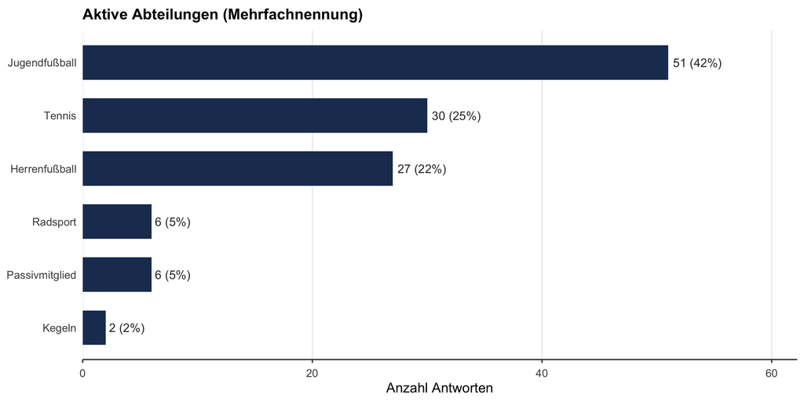

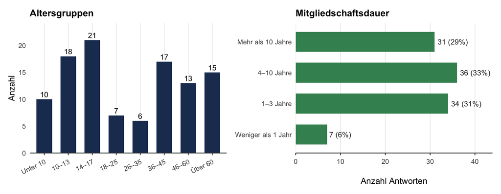

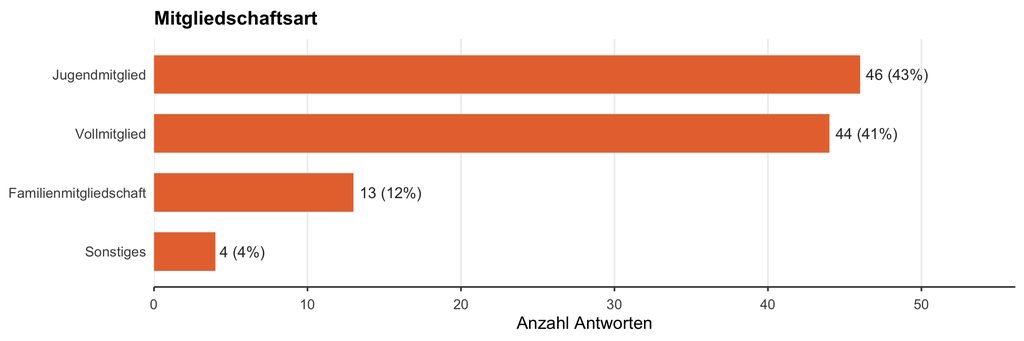

## 2 · Was der Verein den Mitgliedern bedeutet

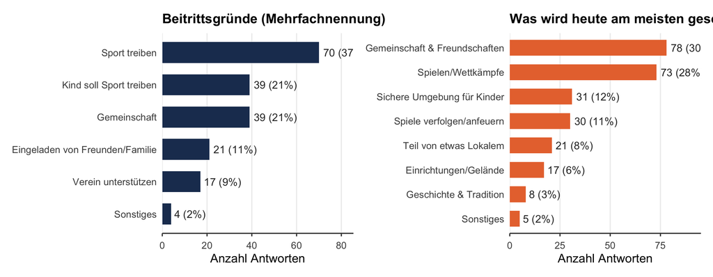

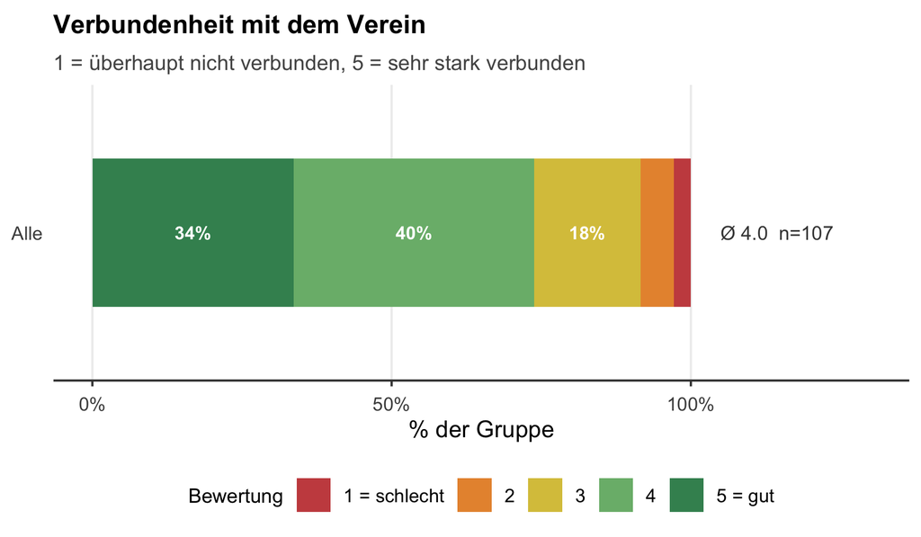

> **Ø 3.96** von 5. In den Freitextantworten werden zwei Hauptwünsche für mehr Verbundenheit genannt: ein gemeinsamer Treffpunkt mit Gastronomie sowie mehr abteilungsübergreifende Veranstaltungen.

## 3 · Die vier Identitätsaussagen

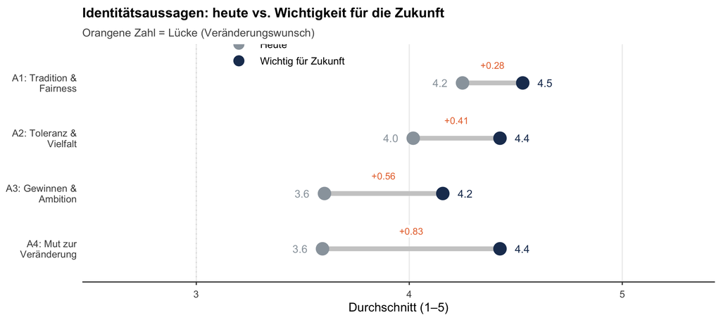

Aussage 4 (Mut zur Veränderung) weist mit **+0.83** die größte Lücke auf. Alle vier Aussagen werden für die Zukunft höher gewichtet als sie heute wahrgenommen werden.

## 4 · Zufriedenheit mit dem Status quo

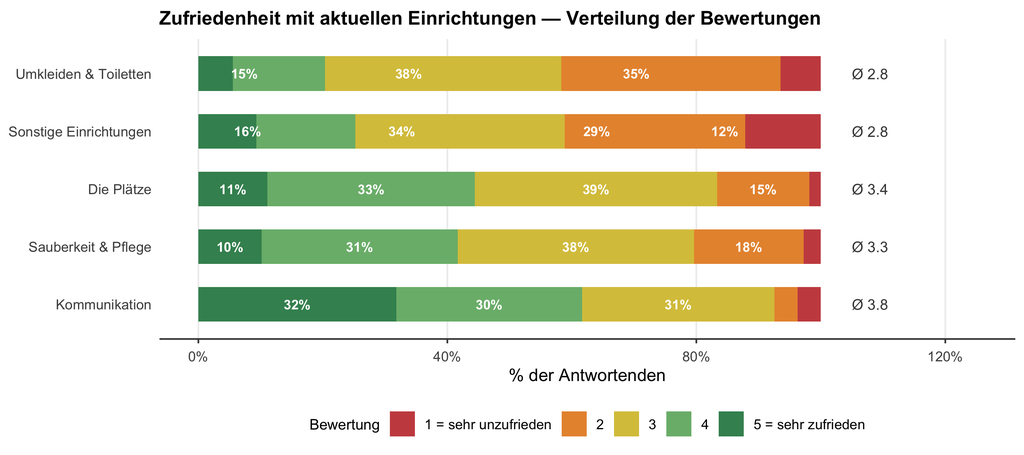

| Bereich | Ø | Einschätzung |
| --- | --- | --- |
| Umkleiden & Toiletten | 2.78 | 🔴 Größter Handlungsbedarf |
| Sonstige Einrichtungen | 2.81 | 🔴 Handlungsbedarf |
| Sauberkeit & Pflege | 3.29 | 🟡 Mittelfeld |
| Die Plätze | 3.37 | 🟡 Mittelfeld |
| Kommunikation | 3.82 | 🟢 Gut bewertet |

## 5 · Ehrenamt und Mitmachen

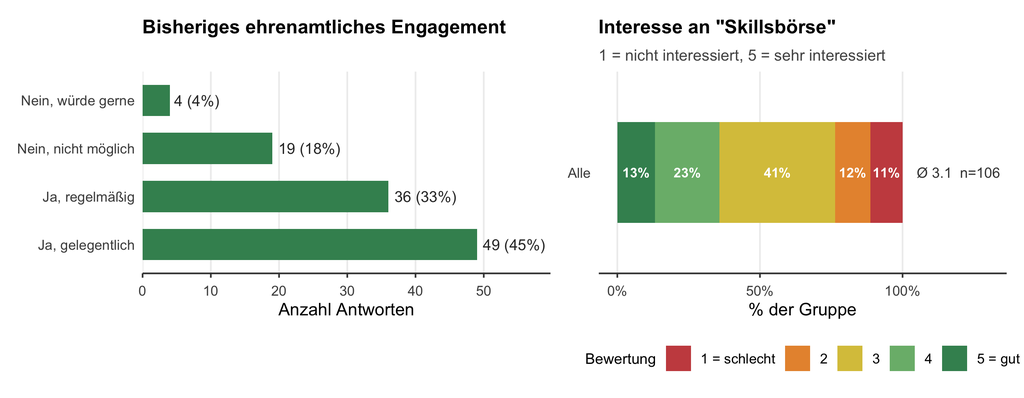

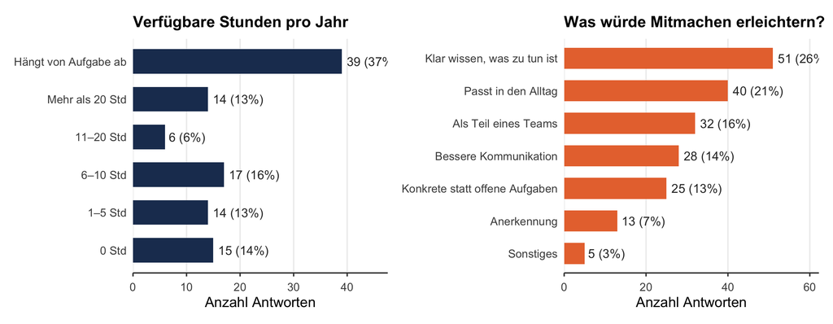

## 6 · Beiträge und Investitionen

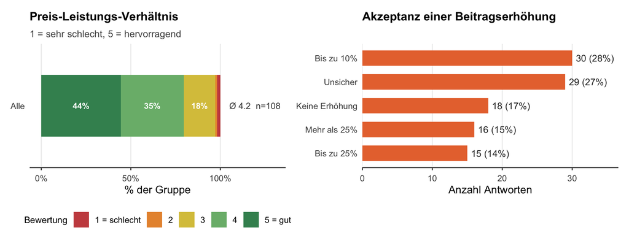

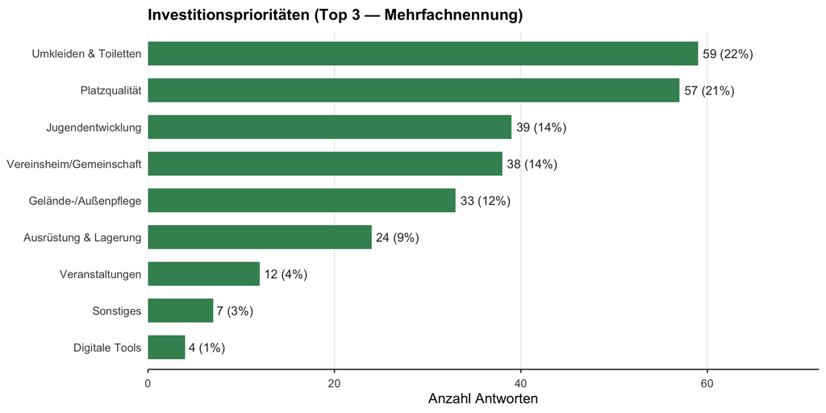

## 7 · Interesse an den Arbeitsgruppen

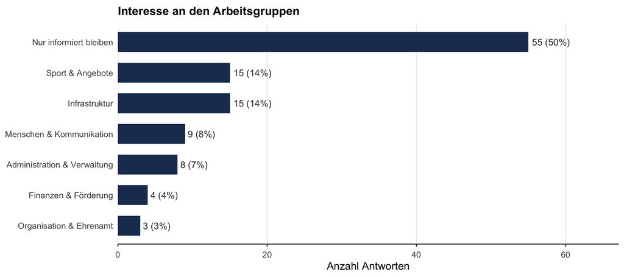